# Data Exploration on Ford GoBike Data in San Francisco Bay Area

## by Reinhold Mauch

## Investigation Overview

This presentation gives insights on the frequency and usage patterns of rides of the  
*Ford GoBike* bike sharing system (now known as Bay Wheels) located in the San Francisco Bay Area on the West Coast of the United States.

All upcoming insights are based on a given dataset of bike rides. The objective was to identify patterns and dependencies within the dataset.  
I'm going to answer following questions:

1. What is the mean and distribution of ride duration?
2. Who is the typical user of the bike share system?
3. What is the typical usage pattern for the bike system?
4. Where do rides start and where do they end?
5. Conclusion

## Dataset Overview

All insights are based on a dataset of bike rides within the **San Francisco Bay Area** in **February 2019**.  
The original dataset contained **183.412** individual bike rides with following information:

- anonymized user data (birth year, membership, gender, enrollment of user in "Bike Share For All Program" for residents with low income)
- bike share station information of around 330 bike stations (id, address, geo-position)
- ride data (start time, end time, start station, end station, ride duration)

## 1. What is the mean and distribution of ride duration?

First things first: Let's get a picture of a typical ride

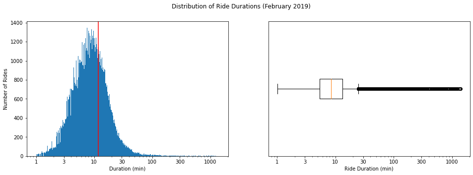

```python
plt.figure(figsize=[16, 5])

ax = plt.subplot(1, 2, 1)
log_binsize = 0.005
log_bins = 10 ** np.arange(-0.005, np.log10(bike_rentals_clean['duration_min'].max()) + log_binsize, log_binsize)

plt.hist(data = bike_rentals_clean, x = 'duration_min', bins = log_bins)
plt.xlabel('Duration (min)')
plt.ylabel('Number of Rides')
plt.xscale('log')
xticks = [1, 3, 10, 30, 100, 300, 1000]
plt.xticks(xticks, xticks)
plt.axvline(bike_rentals_clean.duration_min.mean(), color  = 'red')

ax = plt.subplot(1, 2, 2)
xticks = [1, 3, 10, 30, 100, 300, 1000]
plt.xscale('log')
ax.axes.get_yaxis().set_visible(False)
plt.xticks(xticks, xticks)
plt.boxplot(bike_rentals_clean['duration_min'], vert=False )
plt.xlabel("Ride Duration (min)");
plt.suptitle('Distribution of Ride Durations (February 2019)')
plt.show()
```

- We see a typical ride duration between **5** and **20** minutes with a mean duration of around **12** minutes.
- Ignoring extremely long rides (identified as outliers in box plot) reduces the mean ride time to around **9** min.

## 2. Who is the typical user of the bike share system?

Let's have a look at age, gender and the user type information in the dataset.

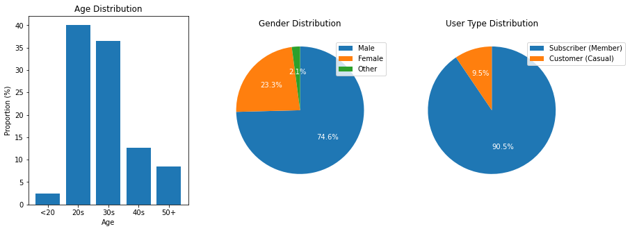

```python
plt.figure(figsize=(14, 5))
base_color = sb.color_palette()[0]
ticks = np.arange(0.00, 0.45, 0.05)
labels = (ticks * 100).astype(int)
ax = plt.subplot(1, 3, 1)
plt.bar(data=df, x='age_level', height='proportion')
#sb.countplot(data = bike_rentals_clean, x = 'age_level', color = base_color, ax = ax)
plt.title('Age Distribution')
ax.set_yticks(ticks)
ax.set_yticklabels(labels)
ax.set_ylabel('Proportion (%)')
ax.set_xlabel('Age')

ax = plt.subplot(1, 3, 2)
sorted_counts = bike_rentals_clean['member_gender'].value_counts()
my_index = sorted_counts.index
wedges, texts, autotexts = plt.pie(sorted_counts, labels = my_index, startangle = 90, counterclock = False, autopct = '%1.1f%%', textprops=dict(color="w"));
plt.title('Gender Distribution')
ax.legend(wedges, my_index,
          loc="upper left",
          bbox_to_anchor=(0.7, 0, 1, 0.95))

ax = plt.subplot(1, 3, 3)
sorted_counts = bike_rentals_clean['user_type'].value_counts()
my_index = ['Subscriber (Member)', 'Customer (Casual)']
wedges, texts, autotexts = plt.pie(sorted_counts, labels = my_index, startangle = 90, counterclock = False, autopct = '%1.1f%%', textprops=dict(color="w"));
plt.title('User Type Distribution')
ax.legend(wedges, my_index,
          loc="upper left",
          bbox_to_anchor=(0.7, 0, 1, 0.95))

plt.show()
```

- Our typical user is in his **20s** or **30s**.
- Around **75%** of users are male, **23%** female and **2%** other gender.
- Only around **10%** of users are sporadic users, **90%** are subsribers

## 3. What is the typical usage pattern for the bike system?

Let's have a look on the usage of bikes throughout the day during the week and on weekends.

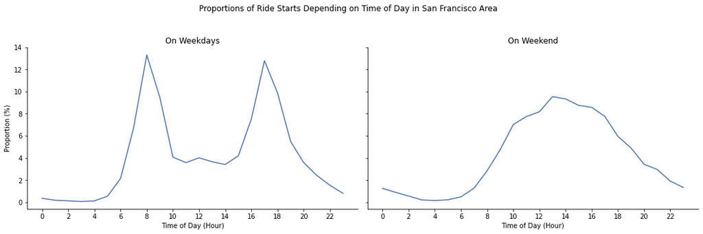

```python
#get values by hour
plot_data = bike_rentals_clean[bike_rentals_clean['location'] == "San Francisco"]

start_hour_counts = bike_rentals_clean.groupby(['part_of_week', 'hour_start']).size().reset_index().rename(columns = {0 : 'counts'})
#get proportions instead of counts
start_hour_counts_totals = start_hour_counts.groupby(['part_of_week'])['counts'].sum()
start_hour_counts['proportion'] = start_hour_counts.apply(lambda x: (x.counts / start_hour_counts_totals[x.part_of_week]), axis = 1)

sb.set_palette('deep')
base_color = sb.color_palette()[0]

g = sb.FacetGrid(data=start_hour_counts, col='part_of_week', height=5, aspect = 1.5, margin_titles = True)
g = g.map(sb.lineplot,'hour_start', 'proportion', color=base_color)

g.fig.subplots_adjust(top=0.8)
g.fig.suptitle('Proportions of Ride Starts Depending on Time of Day in San Francisco Area');
xticks = np.arange(0, 23, 2)
yticks = np.arange(0.00, 0.15, 0.02)
ylabels = (yticks * 100).astype(int)
subplot_titles = ['On Weekdays', 'On Weekend']

for i, ax in enumerate(g.axes.flatten()):
    ax.set_xticks(xticks)
    ax.set_xticklabels(xticks)
    ax.set_yticks(yticks)
    ax.set_yticklabels(ylabels)
    title =ax.get_title()
    ax.set_title(subplot_titles[i])
    ax.set_xlabel('Time of Day (Hour)')
    ax.set_ylabel('Proportion (%)')
    i+=1
```

- We see two distinct usage peaks in the **morning** and **afternoon during the week**.
- On **weekends** there is a completely different usage pattern. Now we have **only one peak in the afternoon**.

## 4.1 Where do ride start and where do they end?

Now we're going to have a look at our bike stations. Where do rides start/end in the morning

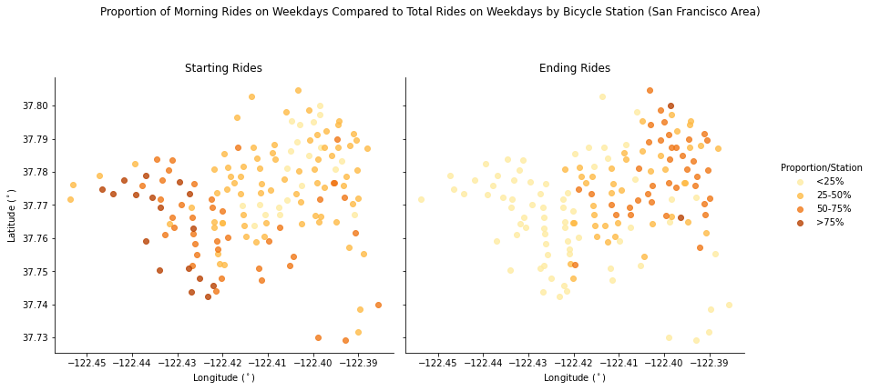

```python
g = sb.FacetGrid(data=plot_1_plot_data, col='station_type', hue ='ride_frequency_on_proportions',
                 height=6, aspect = 1, margin_titles = True, palette = 'YlOrBr')
sb.set_palette('Reds')
g = g.map(sb.regplot,'station_longitude', 'station_latitude', fit_reg = False)

g.fig.subplots_adjust(top=0.8)
g.fig.suptitle('Proportion of Morning Rides on Weekdays Compared to Total Rides on Weekdays by Bicycle Station (San Francisco Area)');
g.add_legend(title='Proportion/Station')

subplot_titles = ['Starting Rides', 'Ending Rides']

for i, ax in enumerate(g.axes.flatten()):

    ax.set_title(subplot_titles[i])
    ax.set_xlabel('Longitude ($^\circ$)')
    if i == 0:
        ax.set_ylabel('Latitude ($^\circ$)')
```

- Stations in the **South/West** show high proportions of **ride starts in the morning**
- Stations in the **North/East** show high proportions of **ride ends in the morning**

## 4.2 Where do rides start and where do they end?

We've learned that there is some sort of movement going on in the morning. What about the afternoon?

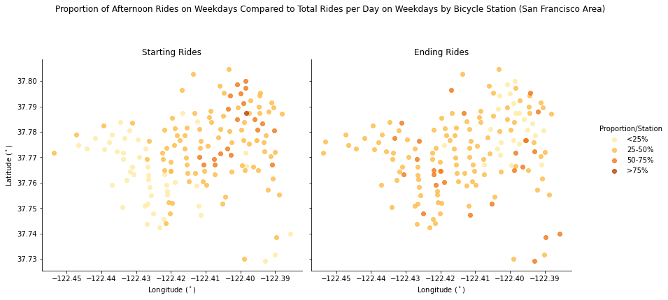

```python
g = sb.FacetGrid(data=plot_2_plot_data, col='station_type', hue ='ride_frequency_on_proportions',
                 height=6, aspect = 1, margin_titles = True, palette = 'YlOrBr')
sb.set_palette('Reds')
g = g.map(sb.regplot,'station_longitude', 'station_latitude', fit_reg = False)

g.fig.subplots_adjust(top=0.8)
g.fig.suptitle('Proportion of Afternoon Rides on Weekdays Compared to Total Rides per Day on Weekdays by Bicycle Station (San Francisco Area)');
g.add_legend(title='Proportion/Station')

subplot_titles = ['Starting Rides', 'Ending Rides']

for i, ax in enumerate(g.axes.flatten()):
    ax.set_title(subplot_titles[i])
    ax.set_xlabel('Longitude ($^\circ$)')
    if i == 0:
        ax.set_ylabel('Latitude ($^\circ$)')
```

- In the **afternoon** stations in the **North/East** show high proportions of **ride starts** and all stations in the **Western part** show higher proportions of **ride ends**
- In the **afternoon** this time the direction seems to be **more spread** but still the **trend is visible**.

## 5. Conclusion

Adding all insights up the dataset indicates a commuter pattern:

- Short rides instead of long rides
- High number of subscribers
- Usage peaks on typical work start and work end hours during the week.
- Completely different pattern on weekends
- Defined direction of travel on usage peaks